# Density kernel depth for outlier detection in functional data

For our generated function space, we use a basic composition of sine waves (with some added random noise):

$X_l(t) = \sum_{j = 1}^4 a_j \cdot \sin (j \pi t) + \epsilon_l(t) $

where $ (a_1, a_2, a_3, a_4) \sim N_4( \mu_a, \Sigma_a) $

```r
library(bigdatadist)
library(parallel)
library(mvtnorm)
```

```r
# function to generate a single function
generate_trajectory <- function(params , N_obs = 1e4){
  t <- 1:N_obs/N_obs
  return(params[1]* sin(pi*t) + params[2]* sin(2*pi*t) + params[3]* sin(3*pi*t) + params[4]* sin(4*pi*t) + rnorm(N_obs, 0, 0.144))
}

generate_data <- function(q, N_traj = 400, N_obs = 1e3){
  main_mu <- c(4, 2, 4, 1)
  main_Sigma <- diag(c(5, 2, 2, 1))
  params <- rmvnorm( N_traj*(1-q), main_mu, main_Sigma)
  main_trajectories <- apply(params, 1, function(param) generate_trajectory(param, N_obs = N_obs))

  magn_mu <- 2.5 * main_mu
  magn_Sigma <- 2.5^2 * main_Sigma
  params2 <- rmvnorm( N_traj*q/2, magn_mu, magn_Sigma)
  magn_trajectories <- apply(params2, 1, function(param) generate_trajectory(param, N_obs = N_obs))

  shape_mu <- c(0, -2, -1, 3)
  shape_Sigma <-  main_Sigma
  params3 <- rmvnorm( N_traj * q/2, shape_mu, shape_Sigma)
  shape_trajectories <- apply(params3, 1, function(param) generate_trajectory(param, N_obs = N_obs))

  trajectories = cbind(main_trajectories, magn_trajectories, shape_trajectories)
  return(trajectories)
}
```

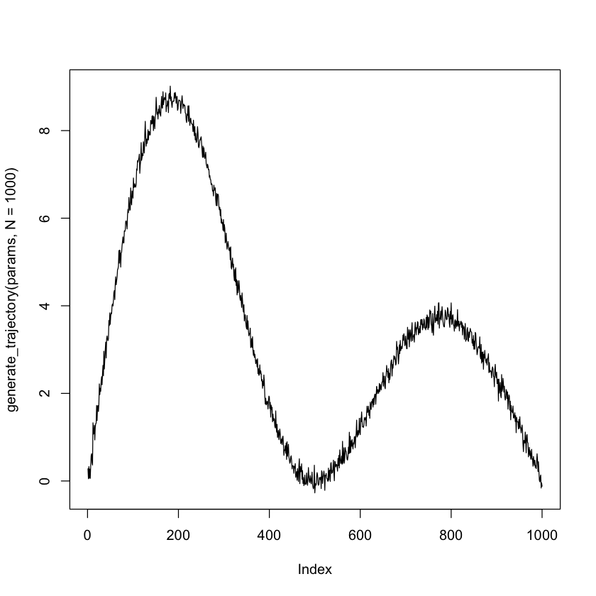

```r
par(bg = "white")
params <- c(4, 2, 4, 1)
plot( generate_trajectory(params, N = 1e3), type = "l")
```

We generate two distinct sets of outliers:

- Magnitude outliers (scaled $\mu_a$ and $\Sigma_a$)
- Shape outliers (completely different $\mu_a$)

```r
# generate data
set.seed(123)
N_obs <- 3e2
N_traj = 1e2
q_true <- 0.2
traj <- generate_data(q_true, N_traj, N_obs)
colnames(traj) <- 1:N_traj
```

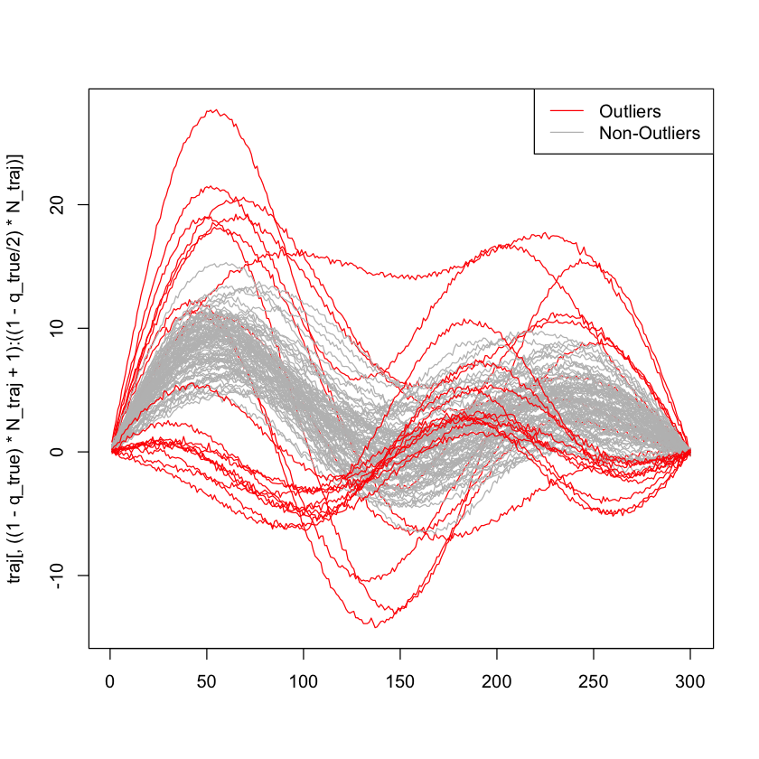

```r
par(bg = "white")

# plot the data (outliers in red and yellow)
matplot(traj[,((1-q_true)*N_traj+1): ((1-q_true/2)*N_traj) ] , lty = 1, col = "red", type = "l")
matlines(traj[,1: ((1-q_true)*N_traj) ] , lty = 1, col = "grey", xlab = "Time", ylab = "Trajectory Value", main = "Trajectories Plot")
matlines(traj[,((1-q_true/2)*N_traj+1):N_traj ] , lty = 1, col = "red")
legend("topright", legend=c("Outliers", "Non-Outliers"), col=c("red", "grey"), lty=1)
```

## An RKHS Framework for Functional Data

Consider a square integrable stochastic process $X(t) \in \mathcal{H}$ in a separable Hilbert space of functions $\mathcal{H} \subset L^2(T)$, where $T \subset \mathbb{R}$ is a compact and convex set. In practice, curves are sampled over a discrete grid of points $t = \{t_1, \ldots, t_p\}$, being $p > 0$, in a signal plus noise fashion as follows:

\begin{equation*} x = x(t) + e, \end{equation*}

where $x = \{x(t_1) + e_1, \ldots, x(t_p) + e_p\}$ is the vector with the observed data and $e = (e_1, \ldots, e_p)$ is an independent and zero-mean residual term.

### Preprocessing Raw Data

Choose an orthogonal basis of functions $B = \{\phi_i\}_{i\geq1}$, where each $\phi_i \in \mathcal{H}$, and represent each functional datum by a linear combination in the $\text{Span}(B)$. A common choice is to consider $\mathcal{H}$ as a Reproducing Kernel Hilbert Space (RKHS) of functions. In this case, the elements in $B$ are the eigenfunctions associated to the positive-definite and symmetric kernel $K: T \times T \rightarrow \mathbb{R}$ that span $\mathcal{H}$.

The functional representation problem is framed as solving the following regularization problem:

\begin{equation*} \hat{x}(t) := \arg\min_{h\in\mathcal{H}} \sum_{j=1}^{p} L(x(t_j), h(t_j))^2 + \gamma \cdot \Delta(h), \end{equation*}

where $L$ is a strictly convex functional, $\gamma > 0$ is a regularization parameter, and $\Delta(h)$ is a regularization term. The solution admits a representation of the form:

\begin{equation*} \hat{x}(t) = \sum_{j=1}^{p} \alpha_j K(t, t_j). \end{equation*}

### Stability and Projection

To ensure stability of coefficients $\alpha$, we apply the Mercer theorem and consider an alternative functional estimator based on the projection of $\hat{x}(t)$ onto the functional space generated by the first $d \leq p$ eigenfunctions of $K$:

\begin{equation*} \tilde{x}(t) = \sum_{j=1}^{d} \lambda_j \phi_j(t) = \lambda^T \Phi(t), \end{equation*}

where $\lambda = (\lambda_1, \ldots, \lambda_d)$ are the projection coefficients, $\Phi(t) = (\phi_1(t), \ldots, \phi_d(t))$ is a vector function with the first $d$ eigenfunctions associated to $K$, and $d \leq p$ is a resolution parameter ensuring $\sup_{t \in T} | \hat{x}(t) - \tilde{x}(t) | \leq \varepsilon_d$.

The computation of depth measures for functional data relies on this projection, specifically on the computation of $\lambda$.

## Depth Measures for Functional Data

Depth measures in statistics quantify the centrality of a point $z \in \mathbb{R}^d$ with respect to a probability distribution $f$, facilitating outlier identification. Notable depth measures for functional data include Integrated Depth, Random Tukey Depth, Random Projection Depth, and h-Mode Depth, among others. These measures leverage various statistical techniques, such as trimmed means, random projections, and kernel distances, to evaluate function centrality.

### Depth Induced by Density Kernels

Given a random vector $Z \in \mathbb{R}^d$ with density function $f$, a function $g: \mathbb{R}^d \rightarrow \mathbb{R}$ is $f$-monotone if it satisfies:

\begin{equation*} f(z) \geq f(y) \Rightarrow g(z, f) \geq g(y, f). \end{equation*}

A density kernel $K_f: \mathbb{R}^d \times \mathbb{R}^d \rightarrow \mathbb{R}$ is the product of two $f$-monotone functions. The Density Kernel Depth (DKD) combines a density kernel with a deepest curve, defining centrality in terms of the mode of $f$ for projection coefficients $\lambda$.

**Definition: Density Kernel Depth**

Let $f$ be the density of projection coefficients $\lambda$, and let $\tilde{x}_{\text{mo}}(t) = \sum_{j=1}^{d} m_j \phi_j(t)$ be the deepest curve, where $m$ represents the mode of $f$. The DKD of curve $\tilde{x}(t) = \lambda^T \Phi(t)$ is defined as:

\begin{equation*} \text{DKD}(\tilde{x}(t), f, K_f) \equiv g(\lambda, f)g(m, f), \end{equation*}

The DKD exhibits desirable properties for depth measures, including maximality at center, monotonicity relative to the deepest function, vanishing at infinity, and invariance under affine transformations.

### Estimating the Density Kernel Depth

The estimation of DKD relies on asymptotically $f$-monotone functions due to the practical intractability of $f$. This involves non-parametric consistent estimators of $f$ based on the One–Class Neighbor Machine (OCNM) for estimating density levels. The DKD is estimated by evaluating the asymptotically $f$-monotone function against projection coefficients, facilitating the ordering of curves around the estimated central curve.

Given a sample of $n$ discretized curves and their projection coefficients, the OCNM estimates density contour clusters, allowing for the identification of the deepest curve. The estimated DKD values order curves in terms of centrality, with higher values indicating closer proximity to the central curve.

\begin{equation*} \text{Estimated DKD}(\tilde{x}(t), D_n, K_f) \equiv g(\lambda, D_n)g(m, D_n), \end{equation*}

where $D_n$ represents the sample data, and $g(\lambda, D_n)$ and $g(m, D_n)$ are based on the OCNM density estimations. This methodology enables a nuanced analysis of functional data, identifying outliers through their deviation from the central curve.

## Outlier detection methodology:

[figure not shown]

```r
# one iteration of outlier detection
spot_outliers <- function(traj, outlier_indices, q = 0.1, B = 50){
N_obs <- dim(traj)[1]
N_traj <- dim(traj)[2]

# functional dataframe
fdf1 = fdframe(t = 1:N_obs/N_obs, Y = traj)

# data depth
kmd.fit <- kmdepth.fd(fdf1)
depths <- kmd.fit$depth[,2]
quantiles <- ecdf(depths)(depths)
probs <- depths/sum(depths)

# bootstrap
bootstrap <- function(traj, B){
  N_traj <- dim(traj)[2]
  idx <- sample(x = 1:N_traj, prob = probs, replace = TRUE)
  bootstrap1 <- traj[, idx]
  return(bootstrap1)
}

# B <- 1e2
bootstrap_sample <- array(0, dim = c(B, N_obs, N_traj))
for(i in 1:B){
  bootstrap_sample[i,,] <- bootstrap(traj)
}

# compute covariance for perturbation
compute_cov <- function(traj, eps){
  N_traj <- dim(traj)[2]
  N_obs <- dim(traj)[1]

  x_mean <- rowMeans(traj)
  mtx <- matrix(0, N_obs, N_obs)

  for(i in 1:N_traj){
    mtx = mtx + eps/N_traj * as.matrix(traj[,i] - x_mean) %*% t(as.matrix(traj[,i] - x_mean))
  }
  return(mtx)
}

# perturbed_bootstrap_sample_parallel <- array(0, dim = c(B, N_obs, N_traj))
# cl <- makeCluster(detectCores() - 1) # Leave one core free to avoid freezing the system
# clusterExport(cl, varlist = c("bootstrap_sample", "compute_cov", "N_traj", "B", "N_obs"))
# clusterEvalQ(cl, library(mvtnorm))

# perturbed_bootstrap_sample_parallel <- parLapply(cl, 1:B, function(i) {
#   cov <- compute_cov(bootstrap_sample[i,,], 0.1)
#   perturbation <- t(rmvnorm(n = N_traj, sigma = cov))
#   bootstrap_sample[i,,] + perturbation
# })

# stopCluster(cl)

perturbed_bootstrap_sample <- array(0, dim = c(B, N_obs, N_traj))
for(i in 1:B){
  cov <- compute_cov(bootstrap_sample[i,,], 0.1)
  perturbation <- t(rmvnorm(n = N_traj, sigma = cov))
  perturbed_bootstrap_sample[i,,] <- bootstrap_sample[i,,]
}



# Convert the list back to an array
# perturbed_bootstrap_sample_parallel <- array(unlist(perturbed_bootstrap_sample_parallel), dim = c(B, N_obs, N_traj))

perturbed_bootstrap_sample_parallel <- perturbed_bootstrap_sample
emp_quantile <- numeric(B)

for(i in 1:B){
  fdf_i <- fdframe(t = 1:N_obs/1e2,Y = perturbed_bootstrap_sample_parallel[i,,])

  kmd.fit_i <- kmdepth.fd(fdf_i)
  depths_i <- kmd.fit_i$depth[,2]
  quantiles_i <- ecdf(depths_i)(depths_i)
  idx <- which.min((quantiles_i - q) * ((quantiles_i - q) > 0))
  emp_quantile[i] <- depths_i[idx]
}

DKD_median <- median(emp_quantile)

return(list( absolute = as.numeric(colnames(traj)[which(depths < DKD_median)]), relative = which(depths < DKD_median)))
# depths
}
```

```r
flag <- 0
temp <- traj
outliers <- c()
while(flag != 1){
  Q <- length(outliers)

  # absolute indices
  new_outliers <- spot_outliers(temp, q = 0.2, B = 1e2)
  outliers <- c(outliers, new_outliers$absolute)

  if(length(new_outliers$absolute) != 0) temp <- temp[, -new_outliers$relative]
  else flag <-1
}
```

```r
outliers
```

1. 81

2. 84

3. 86

4. 88

5. 89

6. 90

7. 96

8. 98

9. 100

10. 51

11. 78

12. 91

13. 92

14. 93

15. 94

16. 95

17. 97

18. 25

19. 67

20. 85

21. 14

22. 38

23. 5

```r
cat("Number of outliers detected" ,length(outliers), "\n")
cat("True number of outliers" , q_true * N_traj, "\n")

cat("Number of true outliers detected", sum(outliers > (1-q_true) * N_traj+1))
```

```
Number of outliers detected 23
True number of outliers 20
Number of true outliers detected 15
```

```r
true_positives <- sum(outliers > (1-q_true) * N_traj+1)
false_positives <- length(outliers) - true_positives
true_negatives <- (1-q_true) * N_traj - false_positives
false_negatives <- q_true * N_traj - true_positives

confusion_matrix <- matrix(c(true_positives, false_negatives, false_positives, true_negatives), nrow = 2, byrow = TRUE)
dimnames(confusion_matrix) <- list(c("Predicted Positive", "Predicted Negative"), c("Actual Positive", "Actual Negative"))

print("Confusion Matrix:")
print(confusion_matrix)
```

[output not shown]

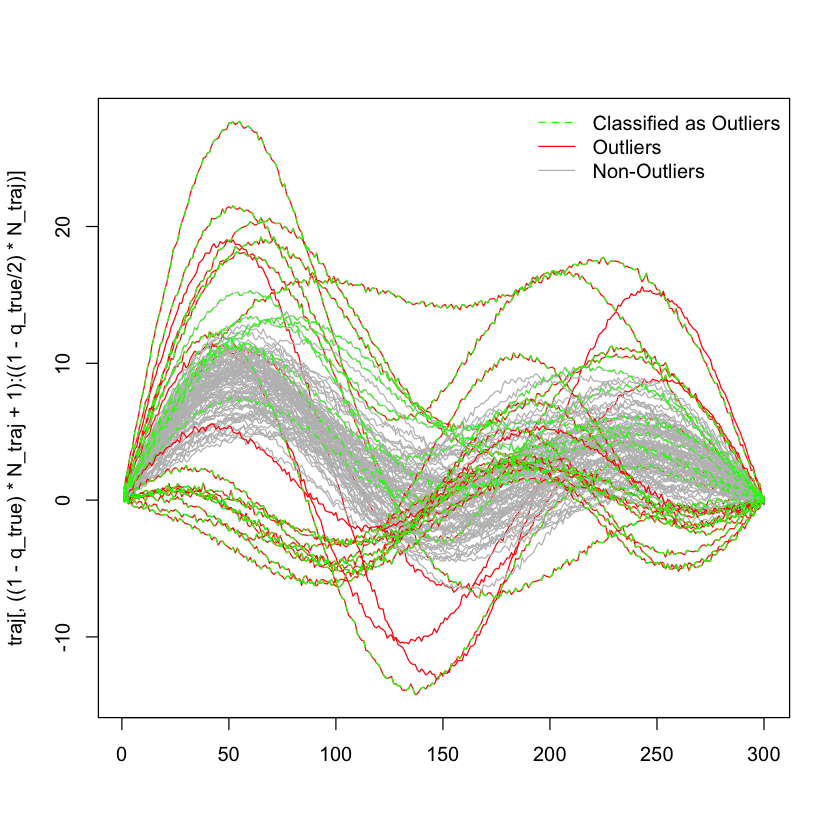

```r
par(bg = "white")
matplot(traj[,((1-q_true)*N_traj+1): ((1-q_true/2)*N_traj) ] , lty = 1, col = "red", type = "l")
matlines(traj[,1: ((1-q_true)*N_traj) ] , lty = 1, col = "grey", xlab = "Time", ylab = "Trajectory Value", main = "Trajectories Plot")
matlines(traj[,((1-q_true/2)*N_traj+1):N_traj ] , lty = 1, col = "red")
matlines(traj[,outliers] , lty = 2, col = "green", alpha = 0.5)
legend("topright", legend = c("Classified as Outliers", "Outliers", "Non-Outliers"),
       col = c("green", "red", "grey"), lty = c(2, 1, 1), bty = "n")
```

There is a tradeoff between speed and accuracy. We can tune parameter q to try to influence the false positive rate. (decreasing q reduces false positives because stricter criterion for classifying as outlier).

### References:

Density kernel depth for outlier detection in functional data: https://link.springer.com/article/10.1007/s41060-023-00420-w